# Biderctional vs. Causal masking (LCLM)

## About this study..

From latent context language model (LCLM), the author highlights that (for encoder attention masking) LCLM performs better on Causal masking set-up than on bidirectional setting.

Since the bidirection makes query to look at entire context or every token, it is natural to think that bidirectional setting would be more accurate. However, the encoder is based on the pre-trained Qwen model which is trained under causal attention, and the pooling from causal attention gives useful hierarchical/accumulating structure to the latent vectors.

From these reasons, we can assume why causal attention performs better than bidirectional attention in LCLM.

To confirm these facts, we will investigate bidirectional and causal attention with pooling on small LCLM.

## Setting

| Component | Setting |
| --- | --- |
| Encoder | small transformer |
| Encoder mask | causal Vs. bidirection |
| Encoder Window | 32 tokens initially |
| Compression | 4x |
| Pooling | mean |
| Adapter | 2 layer MLP |
| Decoder | same small decoder |
| Dataset | synthetic needle retrieval |
| Initialization | identical |
| Training Steps | identical |
| Optimization / LR | identical |

## Architecture

$$X \rightarrow \text{Encoder} \rightarrow H \rightarrow \text{Mean Pool} \rightarrow \text{MLP Adapter} \rightarrow S \rightarrow \text{Decoder} \rightarrow \hat{y}$$

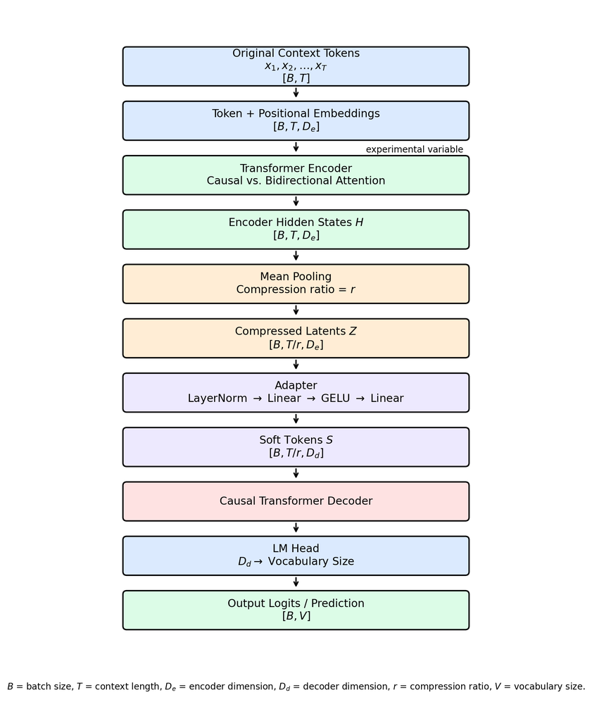

As it is illustrated in the setting and architecture, the only difference is the attention mask in encoder. The other settings are same for both models.

## About the Dataset…

To train and test the model, the needle retrieval task is chosen.

It is a very simple task to train and test the language model. First, we generate random tokens with a specific length (for example, it can be 5 random tokens: [32, 24, 52, 12, 97]). Then, we insert **KEY** in the random position (between numbers, for example: [32, 24, **KEY**, 52, 12, 97]). At the end, with a given query, we train the model to find the number comes after **KEY**.

In addition to the single needle retrieval task, the multi-key retrieval task is also implemented. It is basically same as the single needle retrieval task, but there are several keys in the sample, and the task is to find these keys with given queries (For example: [32,**KEY_A**, 24, **KEY_B**, 52, 12], **QUERY_A** and **QUERY_B** are the task to find the number comes after **KEY_A** and **KEY_B** accordingly.)

So, the experiment looks like

$$\begin{array}{c}
\text{Single after-key Retrieval} \\[6pt]
\downarrow \\[6pt]
\text{Multi after-key Retrieval} \\[6pt]
\downarrow \\[6pt]
\text{Multi before-key Retrieval} \\[6pt]
\downarrow \\[6pt]
\text{Multi before-after-key Retrieval (accessorial task)}
\end{array}$$
Since before-after task introduces extra changes at the same time: two targets instead of one, two output heads instead of one, a harder multitask objective, and a different loss, it becomes harder to know whether the cause was the encoder mask or simply the more difficult two-output task. So, we will focus more on the after-key and before-key Retrieval task.

## Result

For the Single after-key Retrieval task, both models (causal and bidirectional masks) show a high test accuracy and low test loss (1.0 and 0.001 accordingly).

For multi-key retrieval task, 6 different evaluations are measured during training and testing,

1. Test accuracy
2. Test cross-entropy loss
3. Mean probability assigned to correct token
4. accuracy by correct quartile
5. Accuracy by position within 4-token pooling block
6. Training loss/accuracy

### Test loss/accuracy, Mean correct-token probability result

| Task | Encoder Mask | Test Loss | Test Accuracy | Mean Correct-Token Probability |
| --- | --- | --- | --- | --- |
| After-key | Causal | 0.3986 | 0.9245 | 0.9182 |
| After-key | Bidirectional | 0.7317 | 0.8395 | 0.8079 |
| Before-key | Causal | 0.4956 | 0.9055 | 0.8777 |
| Before-key | Bidirectional | 1.5431 | 0.7190 | 0.6978 |

### Accuracy by context/pooling-block position

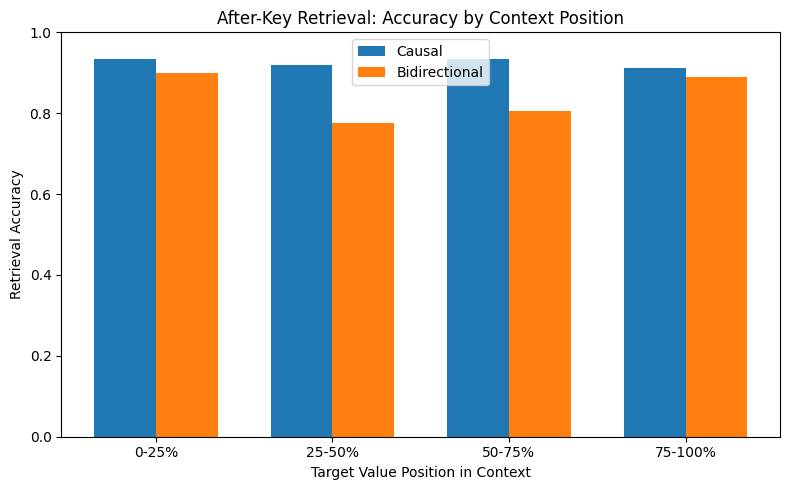

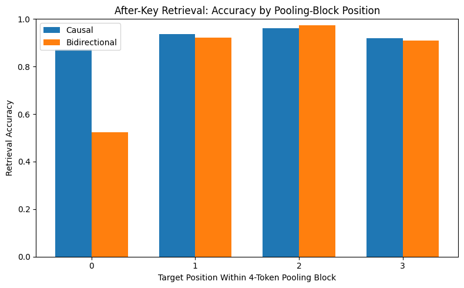

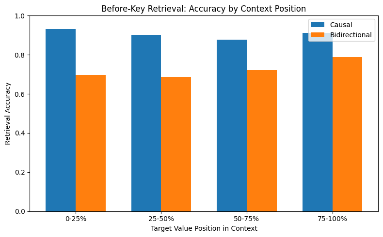

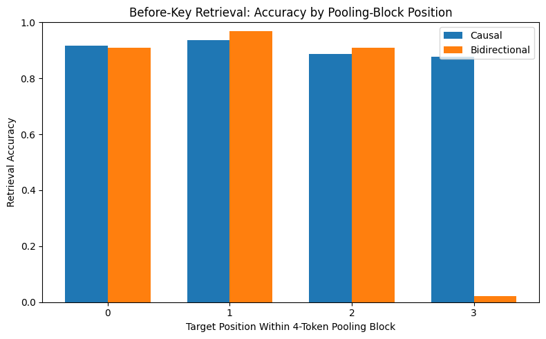

### Training Loss

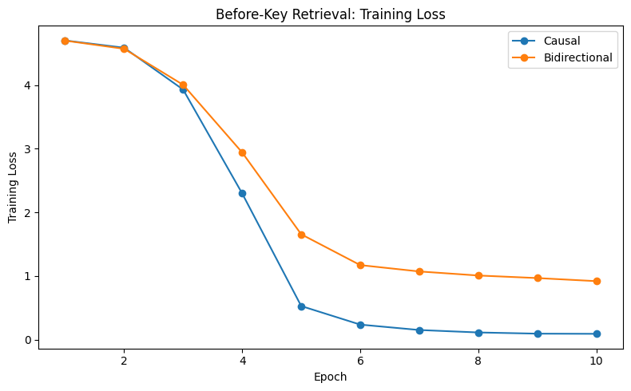

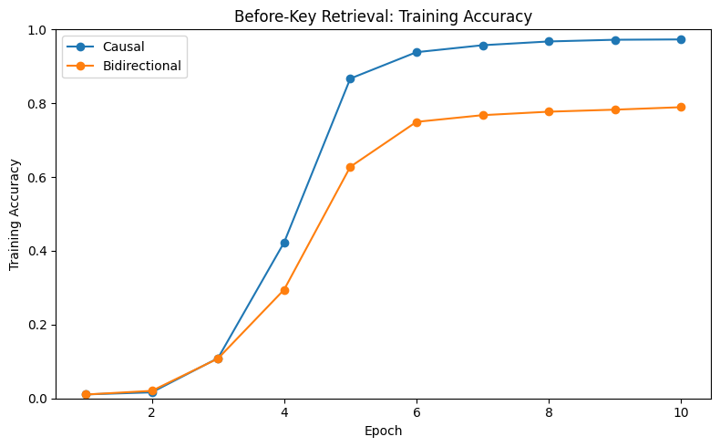

[figure not shown]

[figure not shown]